# data science II midterm project

Muxin Li, Xinyi Yao, Yumeng Lu

2026-03-24

```r
library(tidyverse)
library(mgcv)
library(patchwork)
library(caret)
library(glmnet)
library(earth)
library(pdp)
```

```r
theme_set(
  theme_minimal() +
  theme(
    plot.title = element_text(face = "bold", size = 14, hjust = 0.5),
    legend.position = "bottom"
  )
)

plot_labs = list(
  geom_point(alpha = 0.2),
  geom_smooth(method = "loess", se = TRUE),
  labs(x = NULL, y = "log(PFS)")
)

pretty_table = function(df, caption = NULL) {
  knitr::kable(df, caption = caption, align = "c") |>
    kableExtra::kable_styling(full_width = FALSE, bootstrap_options = c("striped", "hover", "condensed"))
}
```

# (I)

```r
load("datA.RData")

datA= datA|>
  mutate(
    menopause = factor(menopause),
    race = factor(race),
    tumor_grade = factor(tumor_grade),
    ER = factor(ER),
    PR = factor(PR),
    HER2 = factor(HER2),
    stage = factor(stage),
    surgery = factor(surgery),
    chemo = factor(chemo),
    hormonal_therapy = factor(hormonal_therapy)
  )
```

## GAM model

### Step 1: choose linear terms and nonlinear terms briefly.

Menopause, race, tumor_grade, ER, PR, HER2, stage, surgery, chemo, hormonal_therapy are categorical variables. Usually, we can treat as linear terms. For age, bmi, tumor_size, lymph_nodes, and Ki67, we need to find whether they are linear or nonlinear.

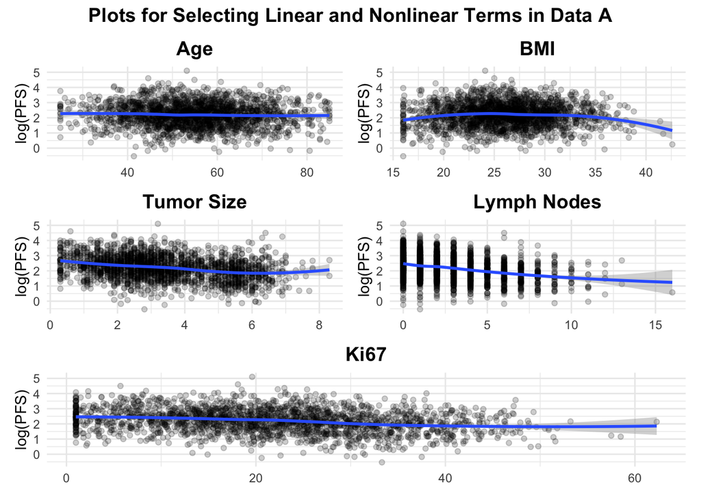

```r
p1 = ggplot(datA, aes(x= age, y= log_PFS)) + plot_labs + labs(title = "Age")
p2 = ggplot(datA, aes(x= bmi, y= log_PFS)) + plot_labs + labs(title = "BMI")
p3 = ggplot(datA, aes(x= tumor_size, y= log_PFS)) + plot_labs + labs(title = "Tumor Size")
p4 = ggplot(datA, aes(x= lymph_nodes, y= log_PFS)) + plot_labs + labs(title = "Lymph Nodes")
p5 = ggplot(datA, aes(x= Ki67, y= log_PFS)) + plot_labs + labs(title = "Ki67")

(p1 | p2) / (p3 | p4) / p5 +
  plot_annotation(title = "Plots for Selecting Linear and Nonlinear Terms in Data A")
```

Comment: From the plot we find age is linear; lymph_nodes is linear; bmi has a clear curve (first rising and then falling); tumor_size and Ki67 are slightly nonlinear.

### Step 2: choose smooth term exactly.

We are not sure tumor_size and Ki67 are smoothing terms, so we use ANOVA to compare.

```r
m1 = gam(
  log_PFS ~ age + s(bmi) + tumor_size + lymph_nodes + Ki67 + menopause + race + tumor_grade + ER + PR + HER2 + stage + surgery + chemo + hormonal_therapy,
  data = datA
)

m2 = gam(
  log_PFS ~ age + s(bmi) + s(tumor_size) + lymph_nodes + s(Ki67) + menopause + race + tumor_grade + ER + PR + HER2 + stage + surgery + chemo + hormonal_therapy,
  data =datA
)

m_tumor = gam(
  log_PFS ~ age + s(bmi) + s(tumor_size) + lymph_nodes + Ki67 +
    menopause + race + tumor_grade + ER + PR + HER2 + stage +
    surgery + chemo + hormonal_therapy,
  data = datA
)

m_ki67 = gam(
  log_PFS ~ age + s(bmi) + tumor_size + lymph_nodes + s(Ki67) +
    menopause + race + tumor_grade + ER + PR + HER2 + stage +
    surgery + chemo + hormonal_therapy,
  data = datA
)

anova(m1, m2, test = "F")
```

```
## Analysis of Deviance Table
##
## Model 1: log_PFS ~ age + s(bmi) + tumor_size + lymph_nodes + Ki67 + menopause +
##     race + tumor_grade + ER + PR + HER2 + stage + surgery + chemo +
##     hormonal_therapy
## Model 2: log_PFS ~ age + s(bmi) + s(tumor_size) + lymph_nodes + s(Ki67) +
##     menopause + race + tumor_grade + ER + PR + HER2 + stage +
##     surgery + chemo + hormonal_therapy
##   Resid. Df Resid. Dev     Df Deviance      F Pr(>F)
## 1    1976.1     954.04
## 2    1974.7     952.34 1.4481   1.6994 2.4353 0.1047
```

```r
anova(m1, m_tumor, test = "F")
```

```
## Analysis of Deviance Table
##
## Model 1: log_PFS ~ age + s(bmi) + tumor_size + lymph_nodes + Ki67 + menopause +
##     race + tumor_grade + ER + PR + HER2 + stage + surgery + chemo +
##     hormonal_therapy
## Model 2: log_PFS ~ age + s(bmi) + s(tumor_size) + lymph_nodes + Ki67 +
##     menopause + race + tumor_grade + ER + PR + HER2 + stage +
##     surgery + chemo + hormonal_therapy
##   Resid. Df Resid. Dev     Df Deviance      F Pr(>F)
## 1    1976.1     954.04
## 2    1974.7     952.34 1.4481   1.6994 2.4353 0.1047
```

```r
anova(m1, m_ki67, test = "F")
```

```
## Analysis of Deviance Table
##
## Model 1: log_PFS ~ age + s(bmi) + tumor_size + lymph_nodes + Ki67 + menopause +
##     race + tumor_grade + ER + PR + HER2 + stage + surgery + chemo +
##     hormonal_therapy
## Model 2: log_PFS ~ age + s(bmi) + tumor_size + lymph_nodes + s(Ki67) +
##     menopause + race + tumor_grade + ER + PR + HER2 + stage +
##     surgery + chemo + hormonal_therapy
##   Resid. Df Resid. Dev         Df    Deviance F Pr(>F)
## 1    1976.1     954.04
## 2    1976.1     954.04 7.4776e-09 -1.3358e-10
```

Comment: Although exploratory plots suggested mild nonlinearity for tumor_size and Ki67, model comparisons using ANOVA indicate that smoothing terms do not significantly improve model fit. In particular, the smoothing term for Ki67 has effectively zero degrees of freedom, suggesting a linear relationship. Thus, both variables are retained as linear terms.

### Step 3: summary the model and simplify.

```r
gam_fit1= gam(
  log_PFS ~ age + s(bmi) + tumor_size + lymph_nodes + Ki67 +
    menopause + race + tumor_grade + ER + PR + HER2 + stage +
    surgery + chemo + hormonal_therapy,
  data = datA
)
summary(gam_fit1)
```

```
##
## Family: gaussian
## Link function: identity
##
## Formula:
## log_PFS ~ age + s(bmi) + tumor_size + lymph_nodes + Ki67 + menopause +
##     race + tumor_grade + ER + PR + HER2 + stage + surgery + chemo +
##     hormonal_therapy
##
## Parametric coefficients:
##                     Estimate Std. Error t value Pr(>|t|)
## (Intercept)        2.7210154  0.1110669  24.499  < 2e-16 ***
## age               -0.0041846  0.0019153  -2.185 0.029024 *
## tumor_size        -0.0617453  0.0198687  -3.108 0.001913 **
## lymph_nodes       -0.0659591  0.0097351  -6.775 1.63e-11 ***
## Ki67              -0.0038725  0.0019844  -1.951 0.051143 .
## menopause1         0.0396511  0.0468592   0.846 0.397557
## race2              0.0372369  0.0454275   0.820 0.412487
## race3              0.0641768  0.0561219   1.144 0.252960
## race4             -0.0388745  0.0481849  -0.807 0.419892
## tumor_grade2      -0.0453329  0.0463990  -0.977 0.328677
## tumor_grade3      -0.1633398  0.0593064  -2.754 0.005938 **
## ER1                0.2344966  0.0515997   4.545 5.84e-06 ***
## PR1               -0.0048347  0.0387555  -0.125 0.900735
## HER21             -0.1717877  0.0386554  -4.444 9.32e-06 ***
## stage2             0.0543338  0.0519110   1.047 0.295378
## stage3             0.0931217  0.1030664   0.904 0.366364
## surgery1          -0.0090098  0.0332095  -0.271 0.786187
## chemo1            -0.0002041  0.0324330  -0.006 0.994980
## hormonal_therapy1  0.1338895  0.0397960   3.364 0.000782 ***
## ---
## Signif. codes:  0 '***' 0.001 '**' 0.01 '*' 0.05 '.' 0.1 ' ' 1
##
## Approximate significance of smooth terms:
##          edf Ref.df     F p-value
## s(bmi) 3.905  4.883 7.211 2.8e-06 ***
## ---
## Signif. codes:  0 '***' 0.001 '**' 0.01 '*' 0.05 '.' 0.1 ' ' 1
##
## R-sq.(adj) =  0.213   Deviance explained = 22.2%
## GCV = 0.48814  Scale est. = 0.48255   n = 2000
```

Comment: Ki67, menopause, race, tumor_grade2, PR, stage, surgery, chemo are not statistically significant and could be excluded from the model. The model explained 21.3% of the variability of the outcome (R^2= 0.213).

```r
gam_fit2 = gam(
  log_PFS ~ age + s(bmi) + tumor_size + lymph_nodes + tumor_grade + ER + HER2 + hormonal_therapy,
  data = datA
)

summary(gam_fit2)
```

```
##
## Family: gaussian
## Link function: identity
##
## Formula:
## log_PFS ~ age + s(bmi) + tumor_size + lymph_nodes + tumor_grade +
##     ER + HER2 + hormonal_therapy
##
## Parametric coefficients:
##                    Estimate Std. Error t value Pr(>|t|)
## (Intercept)        2.616320   0.090610  28.875  < 2e-16 ***
## age               -0.002942   0.001343  -2.190 0.028622 *
## tumor_size        -0.049378   0.012886  -3.832 0.000131 ***
## lymph_nodes       -0.063182   0.008538  -7.400 1.99e-13 ***
## tumor_grade2      -0.074679   0.042897  -1.741 0.081857 .
## tumor_grade3      -0.228148   0.045541  -5.010 5.93e-07 ***
## ER1                0.260201   0.042756   6.086 1.39e-09 ***
## HER21             -0.174936   0.038492  -4.545 5.83e-06 ***
## hormonal_therapy1  0.136634   0.039529   3.457 0.000559 ***
## ---
## Signif. codes:  0 '***' 0.001 '**' 0.01 '*' 0.05 '.' 0.1 ' ' 1
##
## Approximate significance of smooth terms:
##          edf Ref.df     F p-value
## s(bmi) 3.885  4.859 7.067   4e-06 ***
## ---
## Signif. codes:  0 '***' 0.001 '**' 0.01 '*' 0.05 '.' 0.1 ' ' 1
##
## R-sq.(adj) =  0.214   Deviance explained = 21.9%
## GCV = 0.48529  Scale est. = 0.48217   n = 2000
```

```r
anova(gam_fit1,gam_fit2, test= "F")
```

```
## Analysis of Deviance Table
##
## Model 1: log_PFS ~ age + s(bmi) + tumor_size + lymph_nodes + Ki67 + menopause +
##     race + tumor_grade + ER + PR + HER2 + stage + surgery + chemo +
##     hormonal_therapy
## Model 2: log_PFS ~ age + s(bmi) + tumor_size + lymph_nodes + tumor_grade +
##     ER + HER2 + hormonal_therapy
##   Resid. Df Resid. Dev      Df Deviance      F Pr(>F)
## 1    1976.1     954.04
## 2    1986.1     958.12 -10.024  -4.0845 0.8445 0.5858
```

Comment: Although the reduced model has slightly higher residual deviance, the difference is not statistically significant (p = 0.5858). This suggests that the excluded variables do not contribute meaningfully to model performance. Therefore, the simpler model is preferred, achieving a better balance between model fit and complexity. We choose gam_fit2 as final gam model.

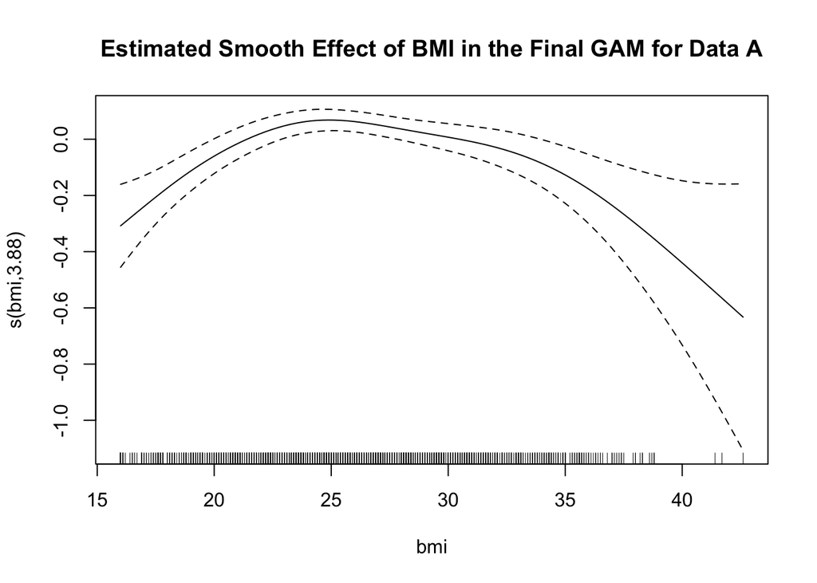

```r
plot(gam_fit2)
title("Estimated Smooth Effect of BMI in the Final GAM for Data A")
```

## LM model

### Step 1: build the LM model

```r
lm_fit= lm(
  log_PFS ~  age + bmi + tumor_size + lymph_nodes + tumor_grade + ER + HER2 + hormonal_therapy,
  data = datA
)

summary(lm_fit)
```

```
##
## Call:
## lm(formula = log_PFS ~ age + bmi + tumor_size + lymph_nodes +
##     tumor_grade + ER + HER2 + hormonal_therapy, data = datA)
##
## Residuals:
##      Min       1Q   Median       3Q      Max
## -2.82120 -0.48336  0.01155  0.46708  2.73052
##
## Coefficients:
##                    Estimate Std. Error t value Pr(>|t|)
## (Intercept)        2.579825   0.124840  20.665  < 2e-16 ***
## age               -0.002880   0.001354  -2.127 0.033532 *
## bmi                0.001406   0.003462   0.406 0.684597
## tumor_size        -0.051536   0.012989  -3.968 7.52e-05 ***
## lymph_nodes       -0.061792   0.008604  -7.182 9.69e-13 ***
## tumor_grade2      -0.078086   0.043245  -1.806 0.071118 .
## tumor_grade3      -0.228888   0.045920  -4.985 6.75e-07 ***
## ER1                0.260743   0.043093   6.051 1.72e-09 ***
## HER21             -0.172948   0.038802  -4.457 8.77e-06 ***
## hormonal_therapy1  0.138938   0.039830   3.488 0.000497 ***
## ---
## Signif. codes:  0 '***' 0.001 '**' 0.01 '*' 0.05 '.' 0.1 ' ' 1
##
## Residual standard error: 0.7003 on 1990 degrees of freedom
## Multiple R-squared:  0.2041, Adjusted R-squared:  0.2005
## F-statistic:  56.7 on 9 and 1990 DF,  p-value: < 2.2e-16
```

### Step 2: compare with GAM model

```r
set.seed(123)

folds = createFolds(datA$log_PFS, k = 10, list = TRUE)

cv_mse_lm  = numeric(10)
cv_mse_gam = numeric(10)

for(i in 1:10) {
  valid_idx = folds[[i]]

  cv_train = datA[-valid_idx, ]
  cv_valid = datA[valid_idx, ]

  lm_cv = lm(
    log_PFS ~ age + bmi + tumor_size + lymph_nodes +
      tumor_grade + ER + HER2 + hormonal_therapy,
    data = cv_train
  )

  gam_cv = gam(
    log_PFS ~ age + s(bmi) + tumor_size + lymph_nodes +
      tumor_grade + ER + HER2 + hormonal_therapy,
    data = cv_train
  )

  pred_lm  = predict(lm_cv, newdata = cv_valid)
  pred_gam = predict(gam_cv, newdata = cv_valid)

  cv_mse_lm[i]  = mean((cv_valid$log_PFS - pred_lm)^2)
  cv_mse_gam[i] = mean((cv_valid$log_PFS - pred_gam)^2)
}

mse_lm= mean(cv_mse_lm)
mse_lm
```

```
## [1] 0.4930619
```

```r
mse_gam= mean(cv_mse_gam)
mse_gam
```

```
## [1] 0.4857952
```

Comment: Under 10-fold cross-validation, the GAM model achieved a slightly lower mean squared error (0.486) compared to the linear model (0.493), indicating improved predictive performance. This suggests that modeling bmi with a nonlinear smooth term provides a modest benefit.

## Penalized Regression Model

### Step 1: find the x and y

```r
x = model.matrix(
  log_PFS ~ age + bmi + tumor_size + lymph_nodes + Ki67 +
    menopause + race + tumor_grade + ER + PR + HER2 +
    stage + surgery + chemo + hormonal_therapy,
  data = datA
)[, -1]

y = datA$log_PFS
```

### Step 2: build Lasso and Ridge

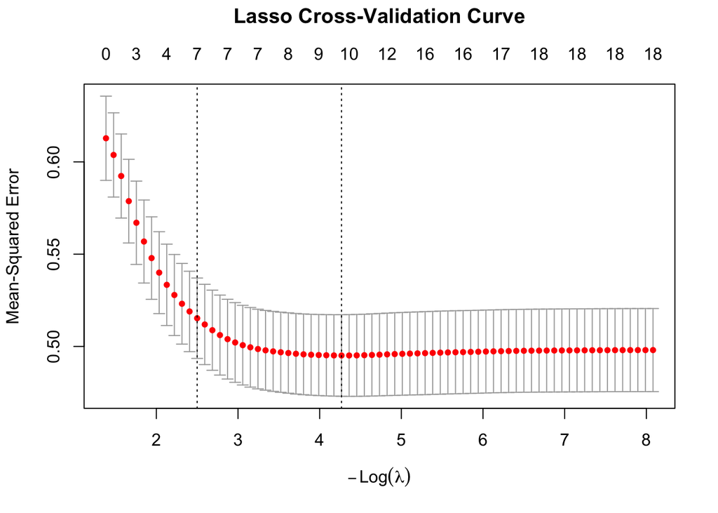

```r
set.seed(123)

cv_lasso= cv.glmnet(x, y, alpha = 1)

plot(cv_lasso)
title("Lasso Cross-Validation Curve", line = 3)
```

```r
cv_lasso$lambda.min
```

```
## [1] 0.01401631
```

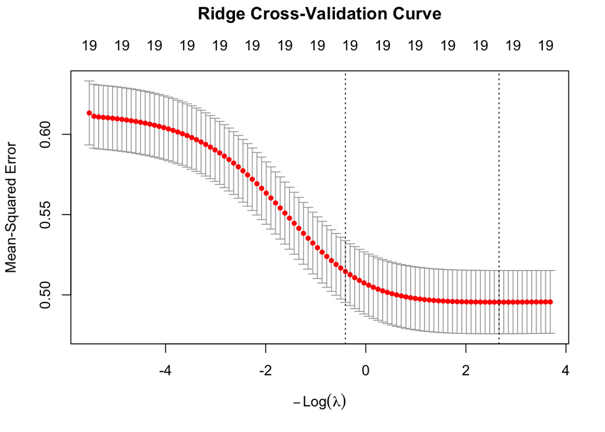

```r
cv_ridge = cv.glmnet(x, y, alpha = 0)

plot(cv_ridge)
title("Ridge Cross-Validation Curve", line = 3)
```

### Step 3: compare with other model

```r
pred_lasso = predict(cv_lasso, x, s = "lambda.min")
pred_ridge = predict(cv_ridge, x, s = "lambda.min")

mse_lasso = mean((y - pred_lasso)^2)
mse_ridge = mean((y - pred_ridge)^2)

mse_lasso
```

```
## [1] 0.4882188
```

```r
mse_ridge
```

```
## [1] 0.487001
```

Comment: Among the penalized regression models, Ridge achieved a slightly lower MSE (0.487) than Lasso (0.488), indicating marginally better predictive performance. For mse: GAM < Ridge < Lasso < LM.

## MARS Model

### Step 1: find the best model

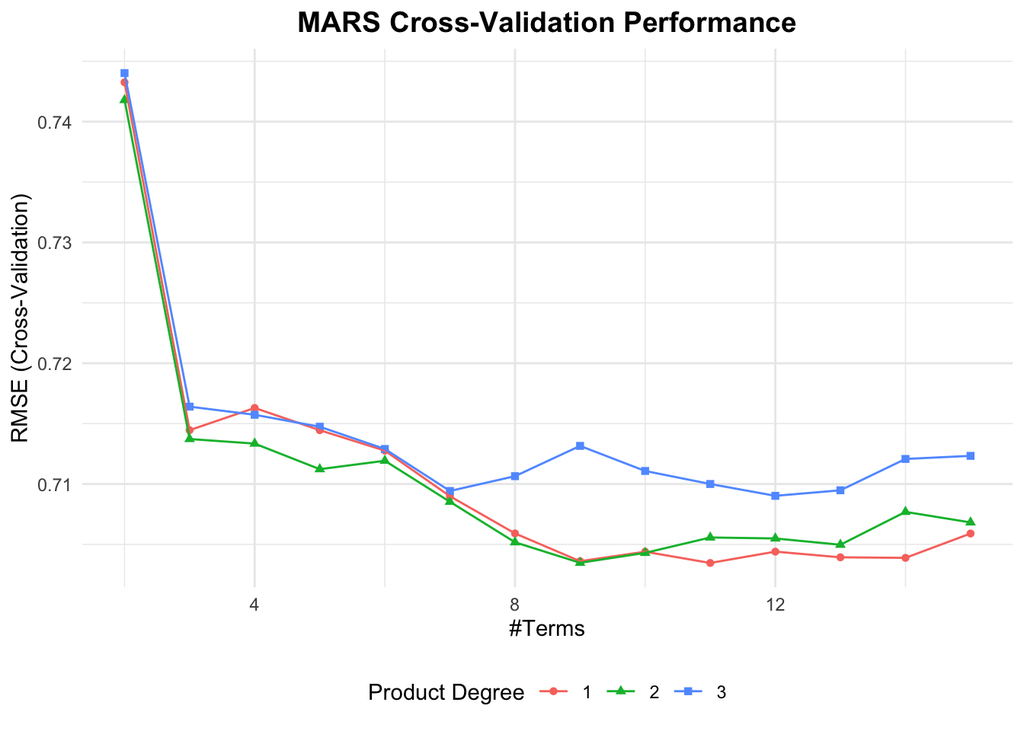

```r
ctrl1 = trainControl(method = "cv", number = 10)

mars_grid = expand.grid(
  degree = 1:3,
  nprune = 2:15
)

set.seed(123)

mars_fit = train(
  log_PFS ~ age + bmi + tumor_size + lymph_nodes + Ki67 + menopause + race + tumor_grade + ER + PR + HER2 + stage + surgery + chemo + hormonal_therapy,
  data = datA,
  method = "earth",
  tuneGrid = mars_grid,
  trControl = ctrl1
)

ggplot(mars_fit) +
  labs(title = "MARS Cross-Validation Performance")
```

```r
mars_fit$bestTune
```

```
##    nprune degree
## 10     11      1
```

```r
coef(mars_fit$finalModel)
```

```
##       (Intercept)  h(6-lymph_nodes)               ER1       h(bmi-23.9)
##        2.09077991        0.07748798        0.22755947       -0.02110819
##       h(23.9-bmi)      h(Ki67-33.8)             HER21 hormonal_therapy1
##       -0.05003047        0.02610809       -0.18465081        0.13632405
##      tumor_grade3 h(tumor_size-0.4)      h(Ki67-24.1)
##       -0.11666085       -0.04882760       -0.01789249
```

Comment: The optimal MARS model has degree = 1, indicating that no interaction terms are needed and the model is additive. The best model has 11 basis functions.

### Step 2 : get mse to compare with other model

```r
best_rmse_mars = mars_fit$results |>
  dplyr::filter(
    nprune == mars_fit$bestTune$nprune,
    degree == mars_fit$bestTune$degree
  ) |>
  dplyr::pull(RMSE)

best_mse_mars = best_rmse_mars^2
best_mse_mars
```

```
## [1] 0.4948591
```

Comment: To compare with other model, we choose MSE. We find MSE for MARS is 0.4948591.

## Different model MSE

```r
model_mse_a = data.frame(
  Model = c("LM", "GAM", "Ridge", "Lasso", "MARS"),
  MSE = c(mse_lm, mse_gam, mse_ridge, mse_lasso, best_mse_mars))|>
  arrange(MSE)

pretty_table(model_mse_a, caption = "Model Comparison by MSE for Data A")
```

Model Comparison by MSE for Data A

| Model | MSE |
| --- | --- |
| GAM | 0.4857952 |
| Ridge | 0.4870010 |
| Lasso | 0.4882188 |
| LM | 0.4930619 |
| MARS | 0.4948591 |

Comment: For MSE comparison among five different models, GAM < Ridge < Lasso < LM < MARS. In this analysis, the generalized additive model (GAM) achieved the lowest mean squared error, indicating that modeling smooth nonlinear relationships—particularly for BMI—provides the greatest improvement in prediction accuracy. Ridge and Lasso regression offered modest improvements over the linear model by stabilizing coefficients and performing variable selection, but their gains were limited. In contrast, the MARS model, which captures nonlinearity through piecewise linear functions, performed worse than the GAM, suggesting that the underlying relationships are smooth rather than threshold-based.

# (II)

## Evaluate prediction model on dataset B

```r
load("datB.RData")
```

```r
datB = datB |>
  mutate(across(c(menopause, race, tumor_grade, ER, PR, HER2,
                  stage, surgery, chemo, hormonal_therapy), factor))

# External Validation: Apply Model A to Data B
pred_B_ext = predict(gam_fit2, newdata = datB)

mse_ext = mean((datB$log_PFS - pred_B_ext)^2)
rmse_ext = sqrt(mse_ext)
r2_ext = cor(datB$log_PFS, pred_B_ext)^2

# Internal Validation: Build New Model for Data B
# Using the same GAM structure to ensure comparability
gam_fit_B = gam(
  log_PFS ~ age + s(bmi) + tumor_size + lymph_nodes + tumor_grade +
    ER + HER2 + hormonal_therapy,
  data = datB
)

summary_B = summary(gam_fit_B)
r2_B = summary_B$r.sq

# Comparison Table
mse_comparison = data.frame(
  `Data Set` = c("Data A", "Data B"),
  MSE = c(best_mse_mars, mse_ext))
coef_A = as.data.frame(summary(gam_fit2)$p.coeff)
coef_B = as.data.frame(summary_B$p.coeff)
comparison_coefs = cbind(coef_A, coef_B)
colnames(comparison_coefs) = c("Beta_1990s", "Beta_2000s")

pretty_table(mse_comparison, caption = "External Validation MSE Comparison")
```

External Validation MSE Comparison

| Data.Set | MSE |
| --- | --- |
| Data A | 0.4948591 |
| Data B | 0.7057918 |

```r
pretty_table(comparison_coefs, caption = "Coefficient Comparison Between Data A and Data B")
```

Coefficient Comparison Between Data A and Data B

|  | Beta_1990s | Beta_2000s |
| --- | --- | --- |
| (Intercept) | 2.6163205 | 2.9869736 |
| age | -0.0029420 | -0.0038004 |
| tumor_size | -0.0493779 | -0.0591790 |
| lymph_nodes | -0.0631821 | -0.0314432 |
| tumor_grade2 | -0.0746786 | 0.0323765 |
| tumor_grade3 | -0.2281479 | -0.2017433 |
| ER1 | 0.2602014 | 0.2158351 |
| HER21 | -0.1749359 | 0.0364582 |
| hormonal_therapy1 | 0.1366341 | 0.2144125 |

```r
cat("R Square:", r2_B)
```

```
## R Square: 0.1836521
```

The model does not generalize well. While the model still captures the general direction of most clinical risks, the significant increase in error and the dramatic shift in specific biological predictors (like HER2) suggest that a model trained on 1990s “medical reality” is no longer calibrated for the 2000s.

### Changes in Prediction

By comparing the 1990s coefficients ($\beta_{1990s}$) with the newly trained 2000s coefficients ($\beta_{2000s}$), we can identify several critical shifts in breast cancer research and treatment:

- **The “HER2 Revolution”** The most striking change is the **HER2 status**. In the 1990s, HER2-positive status was a strong negative prognostic factor ($\beta = -0.1749$). However, in the 2000s model, the coefficient flipped to slightly positive ($\beta = 0.0365$).

**Clinical Interpretation:** This shift is almost certainly due to the clinical introduction of **Trastuzumab (Herceptin)** in the late 1990s. HER2-positive patients, who previously had the worst outcomes, began receiving targeted therapy that effectively neutralized the biological risk of the HER2 protein, fundamentally altering the survival landscape.

- **Management of Nodal Disease** The negative impact of **Lymph Node** involvement significantly decreased, with the coefficient moving from **-0.0632** to **-0.0314**.

**Clinical Interpretation:** This suggests that systemic treatments (chemotherapy and newer targeted agents) in the early 2000s became more effective at treating micrometastatic disease, making the presence of positive lymph nodes less of a “death sentence” for PFS than it was a decade prior.

- **Potency of Hormonal Therapy** The protective effect of **Hormonal Therapy** increased from **0.1366** to **0.2144**.

**Clinical Interpretation:** This likely reflects the transition from Tamoxifen as the sole standard of care to the widespread use of **Aromatase Inhibitors (AIs)** (e.g., Letrozole, Anastrozole) for post-menopausal women, which clinical trials proved to be more effective at preventing recurrence.

- **Baseline Survival Improvement (The Intercept)** The model **Intercept** increased from **2.616** to **2.987**.

**Clinical Interpretation:** This “baseline” jump indicates a general improvement in progression-free survival across the board, likely due to better diagnostic imaging, earlier detection, and improved supportive care (e.g., managing treatment side effects).

## Build a New Prediction model for the 2000-2005 cohort.

### Choose linear terms and nonlinear terms

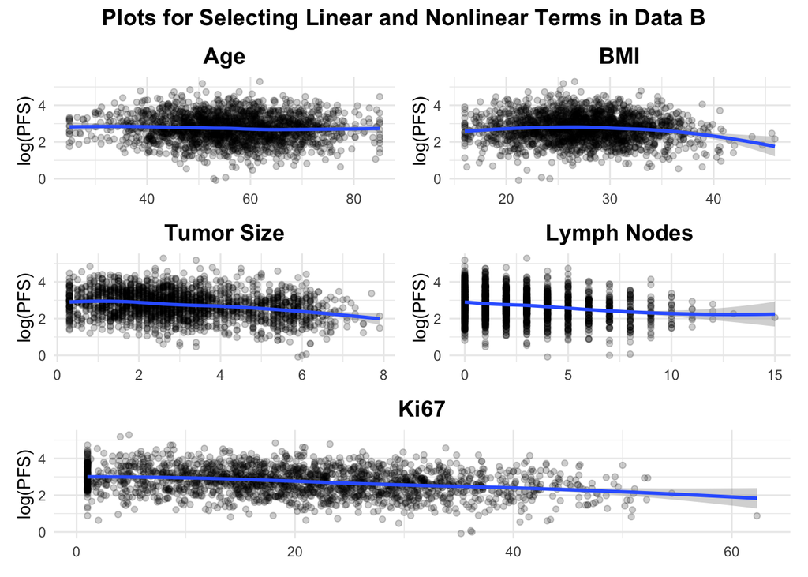

```r
p1_b = ggplot(datB, aes(x = age, y = log_PFS)) + plot_labs + labs(title = "Age")
p2_b = ggplot(datB, aes(x = bmi, y = log_PFS)) + plot_labs + labs(title = "BMI")
p3_b = ggplot(datB, aes(x = tumor_size, y = log_PFS)) + plot_labs + labs(title = "Tumor Size")
p4_b = ggplot(datB, aes(x = lymph_nodes, y = log_PFS)) + plot_labs + labs(title = "Lymph Nodes")
p5_b = ggplot(datB, aes(x = Ki67, y = log_PFS)) + plot_labs + labs(title = "Ki67")

(p1_b | p2_b) / (p3_b | p4_b) / p5_b +
  plot_annotation(title = "Plots for Selecting Linear and Nonlinear Terms in Data B")
```

### Build GAM model

```r
m1_b = gam(log_PFS ~ age + s(bmi) + tumor_size + lymph_nodes + Ki67 + menopause + race +
             tumor_grade + ER + PR + HER2 + stage + surgery + chemo + hormonal_therapy, data = datB)

m2_b = gam(log_PFS ~ age + s(bmi) + s(tumor_size) + lymph_nodes + s(Ki67) + menopause + race +
             tumor_grade + ER + PR + HER2 + stage + surgery + chemo + hormonal_therapy, data = datB)

anova(m1_b, m2_b, test = "F")
```

```
## Analysis of Deviance Table
##
## Model 1: log_PFS ~ age + s(bmi) + tumor_size + lymph_nodes + Ki67 + menopause +
##     race + tumor_grade + ER + PR + HER2 + stage + surgery + chemo +
##     hormonal_therapy
## Model 2: log_PFS ~ age + s(bmi) + s(tumor_size) + lymph_nodes + s(Ki67) +
##     menopause + race + tumor_grade + ER + PR + HER2 + stage +
##     surgery + chemo + hormonal_therapy
##   Resid. Df Resid. Dev     Df Deviance      F Pr(>F)
## 1    1977.1     874.35
## 2    1973.5     871.27 3.6523    3.087 1.9162 0.1116
```

### Summary the model

```r
gam_fit_B = gam(
  log_PFS ~ age + s(bmi) + tumor_size + lymph_nodes + tumor_grade + ER + HER2 + hormonal_therapy,
  data = datB
)

summary(gam_fit_B)
```

```
##
## Family: gaussian
## Link function: identity
##
## Formula:
## log_PFS ~ age + s(bmi) + tumor_size + lymph_nodes + tumor_grade +
##     ER + HER2 + hormonal_therapy
##
## Parametric coefficients:
##                    Estimate Std. Error t value Pr(>|t|)
## (Intercept)        2.986974   0.088965  33.575  < 2e-16 ***
## age               -0.003800   0.001334  -2.849 0.004436 **
## tumor_size        -0.059179   0.012883  -4.593 4.63e-06 ***
## lymph_nodes       -0.031443   0.008497  -3.701 0.000221 ***
## tumor_grade2       0.032377   0.038090   0.850 0.395422
## tumor_grade3      -0.201743   0.041812  -4.825 1.51e-06 ***
## ER1                0.215835   0.049979   4.319 1.65e-05 ***
## HER21              0.036458   0.036232   1.006 0.314425
## hormonal_therapy1  0.214412   0.046329   4.628 3.93e-06 ***
## ---
## Signif. codes:  0 '***' 0.001 '**' 0.01 '*' 0.05 '.' 0.1 ' ' 1
##
## Approximate significance of smooth terms:
##          edf Ref.df     F  p-value
## s(bmi) 3.005  3.813 8.163 5.31e-06 ***
## ---
## Signif. codes:  0 '***' 0.001 '**' 0.01 '*' 0.05 '.' 0.1 ' ' 1
##
## R-sq.(adj) =  0.184   Deviance explained = 18.8%
## GCV = 0.44701  Scale est. = 0.44432   n = 2000
```

### Compare GAM and LM models

```r
set.seed(123)
folds_b = createFolds(datB$log_PFS, k = 10, list = TRUE)

cv_mse_lm_b  = numeric(10)
cv_mse_gam_b = numeric(10)

for(i in 1:10) {
  valid_idx = folds_b[[i]]
  train_b = datB[-valid_idx, ]
  test_b = datB[valid_idx, ]

  # LM
  lm_b = lm(log_PFS ~ age + bmi + tumor_size + lymph_nodes + tumor_grade + ER + HER2 + hormonal_therapy, data = train_b)
  # GAM
  gam_b = gam(log_PFS ~ age + s(bmi) + tumor_size + lymph_nodes + tumor_grade + ER + HER2 + hormonal_therapy, data = train_b)

  cv_mse_lm_b[i]  = mean((test_b$log_PFS - predict(lm_b, test_b))^2)
  cv_mse_gam_b[i] = mean((test_b$log_PFS - predict(gam_b, test_b))^2)
}

mse_lm_b = mean(cv_mse_lm_b)
print(mse_lm_b)
```

```
## [1] 0.4527149
```

```r
mse_gam_b = mean(cv_mse_gam_b)
print(mse_gam_b)
```

```
## [1] 0.4465694
```

### Build Ridge, LASSO, and MARS models

```r
x_b = model.matrix(log_PFS ~ age + bmi + tumor_size + lymph_nodes + Ki67 + menopause + race +
                     tumor_grade + ER + PR + HER2 + stage + surgery + chemo + hormonal_therapy, data = datB)[, -1]
y_b = datB$log_PFS

# Ridge & Lasso
cv_lasso_b = cv.glmnet(x_b, y_b, alpha = 1)
cv_ridge_b = cv.glmnet(x_b, y_b, alpha = 0)

# MARS
mars_fit_b = train(
  log_PFS ~ age + bmi + tumor_size + lymph_nodes + Ki67 + menopause + race +
    tumor_grade + ER + PR + HER2 + stage + surgery + chemo + hormonal_therapy,
  data = datB, method = "earth", tuneGrid = mars_grid, trControl = ctrl1
)
```

### Compare models

```r
pred_lasso = predict(cv_lasso_b, x_b, s = "lambda.min")
pred_ridge = predict(cv_ridge_b, x_b, s = "lambda.min")

mse_lasso_b = mean((y_b - pred_lasso)^2)
mse_ridge_b = mean((y_b - pred_ridge)^2)

mse_lasso_b
```

```
## [1] 0.444569
```

```r
mse_ridge_b
```

```
## [1] 0.4456067
```

```r
best_mse_mars_b = (mars_fit_b$results |>
  filter(nprune == mars_fit_b$bestTune$nprune, degree == mars_fit_b$bestTune$degree) |>
  pull(RMSE))^2

best_mse_mars_b
```

```
## [1] 0.4512692
```

```r
model_mse_b = data.frame(
  Model = c("LM", "GAM", "Ridge", "Lasso", "MARS"),
  MSE = c(mse_lm_b, mse_gam_b, mse_ridge_b, mse_lasso_b, best_mse_mars_b)) |>
    arrange(MSE)

pretty_table(model_mse_b, caption = "Model Comparison by MSE for Data B")
```

Model Comparison by MSE for Data B

| Model | MSE |
| --- | --- |
| Lasso | 0.4445690 |
| Ridge | 0.4456067 |
| GAM | 0.4465694 |
| MARS | 0.4512692 |
| LM | 0.4527149 |

Comment: Lasso model achieved the lowest mean squared error, indicating the best performance, so we choose Lasso Regression.

```r
coef_A = as.matrix(coef(cv_lasso, s = "lambda.min"))
coef_B = as.matrix(coef(cv_lasso_b, s = "lambda.min"))

lasso_comparison = data.frame(
  Predictor = rownames(coef_A),
  Beta_1990s = round(coef_A[, 1], 4),
  Beta_2000s = round(coef_B[, 1], 4)
)  |>
  filter(Beta_1990s != 0 | Beta_2000s != 0) |>
  mutate(Status = case_when(
    Beta_1990s != 0 & Beta_2000s == 0 ~ "Dropped in 2000s",
    Beta_1990s == 0 & Beta_2000s != 0 ~ "New in 2000s",
    TRUE ~ "Kept in both"
  ))

pretty_table(lasso_comparison, caption = "Lasso Coefficient Comparison Across Cohorts")
```

Lasso Coefficient Comparison Across Cohorts

|  | Predictor | Beta_1990s | Beta_2000s | Status |
| --- | --- | --- | --- | --- |
| (Intercept) | (Intercept) | 2.5722 | 3.1620 | Kept in both |
| age | age | -0.0018 | -0.0032 | Kept in both |
| bmi | bmi | 0.0000 | -0.0045 | New in 2000s |
| tumor_size | tumor_size | -0.0476 | -0.0595 | Kept in both |
| lymph_nodes | lymph_nodes | -0.0597 | -0.0290 | Kept in both |
| Ki67 | Ki67 | -0.0040 | -0.0053 | Kept in both |
| menopause1 | menopause1 | 0.0000 | -0.0242 | New in 2000s |
| race2 | race2 | 0.0000 | -0.0257 | New in 2000s |
| race3 | race3 | 0.0059 | -0.0233 | Kept in both |
| race4 | race4 | -0.0132 | 0.0855 | Kept in both |
| tumor_grade2 | tumor_grade2 | 0.0000 | 0.0804 | New in 2000s |
| tumor_grade3 | tumor_grade3 | -0.1027 | -0.0894 | Kept in both |
| ER1 | ER1 | 0.2249 | 0.1350 | Kept in both |
| PR1 | PR1 | 0.0000 | 0.0647 | New in 2000s |
| HER21 | HER21 | -0.1428 | 0.0338 | Kept in both |
| stage2 | stage2 | 0.0000 | 0.0175 | New in 2000s |
| surgery1 | surgery1 | 0.0000 | -0.0096 | New in 2000s |
| chemo1 | chemo1 | 0.0000 | -0.0067 | New in 2000s |
| hormonal_therapy1 | hormonal_therapy1 | 0.1192 | 0.2061 | Kept in both |

Comment:

Significant Improvement in Baseline Survival: The model intercept increased substantially from 2.572 to 3.162. This jump indicates that, while controlling for all other clinical covariates (such as age and tumor characteristics), patients in the 2000s cohort exhibited a markedly higher baseline $log(PFS)$ compared to those in the 1990s.

Diminishing Impact of Nodal Metastasis: The coefficient for lymph_nodes narrowed from -0.0597 to -0.0290. While positive lymph node involvement remains a negative prognostic indicator, its relative impact on disease progression was reduced by approximately 50% in the later cohort.

Emergence of New Metabolic and Physiological Predictors: Variables such as bmi and menopause1 (menopausal status), which were excluded from the 1990s model via Lasso regularization (coefficients reduced to zero), emerged as significant predictors in the 2000s model. The inclusion of bmi (-0.0045) and menopause1 (-0.0242) suggests a shift in the clinical landscape where metabolic health and hormonal status have become more critical in determining long-term outcomes.

Reversal of Demographic Prognostic Factors: Most notably, the coefficient for race4 (Hispanic) shifted from a negative indicator (-0.0132) to a positive protective factor (+0.0855). This reversal suggests a fundamental change in the survival outcomes for this demographic, which may be attributed to improved health equity, better access to specialized care, or enhanced therapeutic responses to updated treatment protocols during this decade.